# Week 7: Normal Distribution

## Example 1

To display the probability density function of the standard normal distribution, we do the following

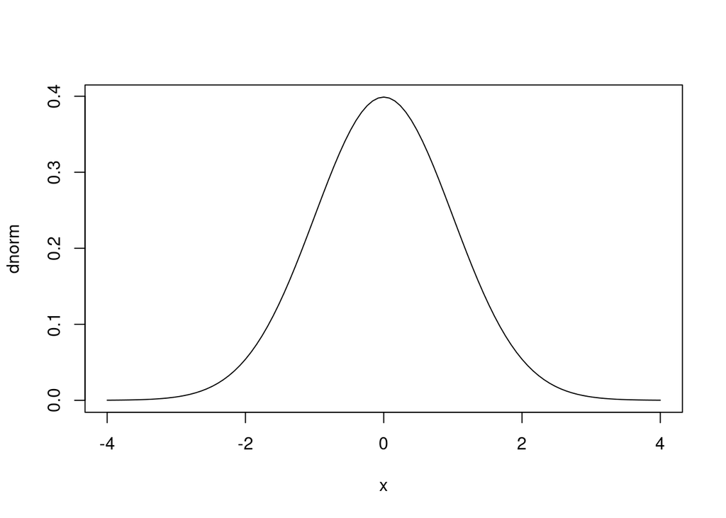

```r
plot(dnorm, xlim = c(-4, 4))
```

To find the area under the curve to the left of a given z, we use the pnorm function. For example, the area to the left of z=1.80 is shown below.

```r
pnorm(1.80)
```

```
## [1] 0.9640697
```

On the other hand, to find what z-score cuts off certain percentage, we use the qnorm function. For example, the z-score that cuts off the bottom 90% is shown below.

```r
qnorm(0.9)
```

```
## [1] 1.281552
```

## Example 2

On page 388 of the OpenStax textbook, the life of CD players is normally distributed with a mean of 4.1 years and a standard deviation of 1.3 years. Find the probability that a CD player will break down in less than 3 years.

We first find the z-score:
$$z=\frac{3-4.1}{1.3}=-0.85$$
We use the pnorm function to find the probability.

```r
pnorm(-0.85)
```

```
## [1] 0.1976625
```

We conclude that the probability is 0.198.

Practice 59 on the same page asks the 70th percentile of the distribution for the time a CD player last. We do so we first find the z-score that cuts off the bottom 70% in a standard normal distribution.

```r
qnorm(0.70)
```

```
## [1] 0.5244005
```

From the z-score, we can find the time by solving the following equation.
$$0.52 = \frac{x-4.1}{1.3}, \quad x = 4.1 + 0.52 \times 1.3 = 4.8.$$

## Follow Up

On page 394 of the OpenStax textbook, it is stated that Facebook found that 28 percent of its users check their profiles before getting out of bed in the morning. Suppose this percentage follows a normal distribution with a standard deviation of five percent. (a) Find the probability that the percent is at least 30. (b) Find the 95th percentile.

© 2022 Frank Wang